# Visualizing Distributions

#### Divide the groups, separate the data

Since we suspect we’re looking at multiple groups from the bimodal distribution, let’s separate the histograms by one of the variables in our data set: continent.

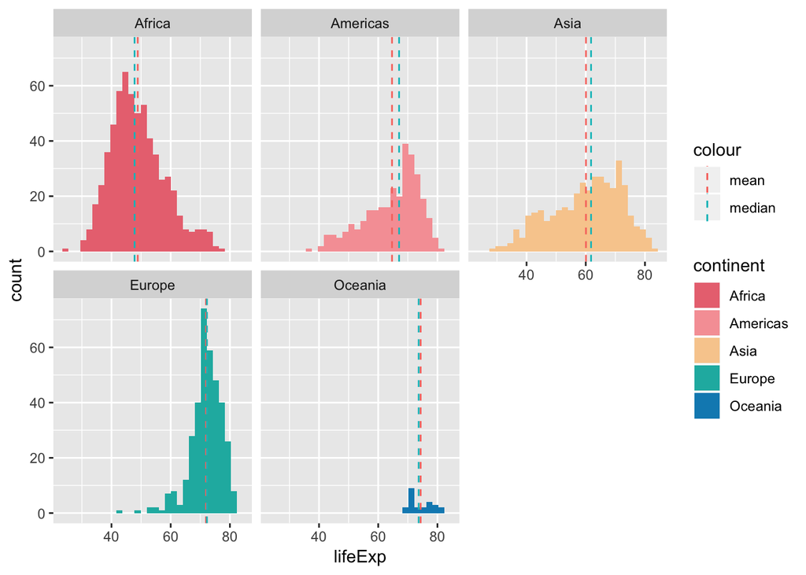

```r
#create a seperate data tabe calculating the mean and median of each continent
measures_of_ct_by_continent <- gapminder %>%
  group_by(continent) %>%
  summarize(mean = mean(lifeExp),
            median = median(lifeExp))

#plot the distribution of life expectancies separated by continent
ggplot(gapminder, aes(lifeExp, fill = continent)) +
  geom_histogram() +
  geom_vline(data = measures_of_ct_by_continent,
             aes(xintercept = mean, color = "mean"),
             linetype = "dashed") +
  geom_vline(data = measures_of_ct_by_continent,
             aes(xintercept = median, color = "median"),
             linetype = "dashed") +
  scale_fill_manual(values = c("Africa" = "#EA7580",
                               "Americas" = "#F6A1A5",
                               "Asia" = "#F8CD9C",
                               "Europe"= "#1BB6AF",
                               "Oceania" = "#088BBE")) +
  facet_wrap(~continent)
```

Now we can see that Africa and Europe have two very distinct averages of life expectancy and were likely driving the bimodal distribution.

### Adjusting the bin width

Adjusting the binwdith of your data can sometimes change the interpretation of your histogram. Here we look at the difference between the life expectancies in Africa with 10 vs. 100 bins

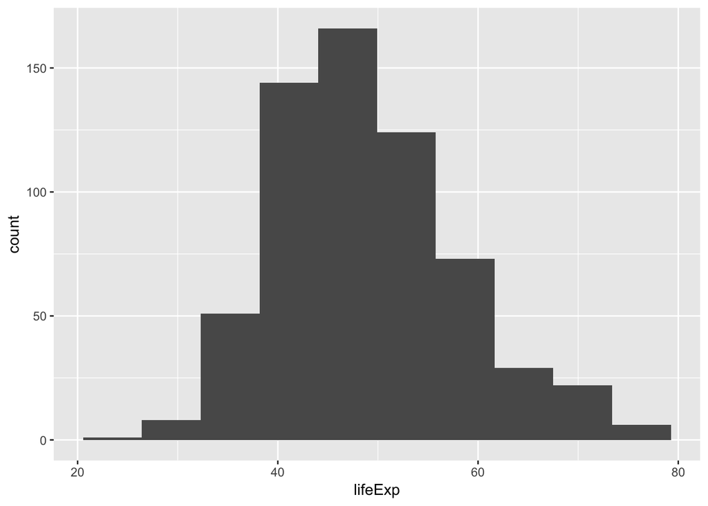

```r
gapminder %>%
  filter(continent == "Africa") %>%
  ggplot(., aes(lifeExp)) +
  geom_histogram(bins = 10)
```

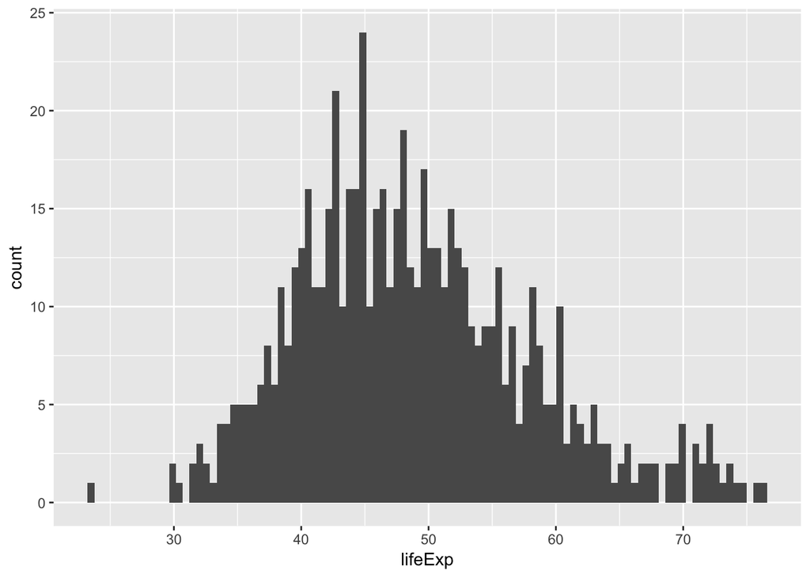

```r
gapminder %>%
  filter(continent == "Africa") %>%
  ggplot(., aes(lifeExp)) +
  geom_histogram(bins = 100)
```

In this case, we see a comb distribution in the histogram with more bins, likely due to rounding of ages to the third decimal.

### Changing the colors of your histogram

Changing the colors of your histogram takes a little familiarity with R programming, click [here](https://lizmcarey.github.io/customizing_plots/) to learn more about customizing plots.

## Density Plots

A density plot is a smoothed version of the histogram. It uses kernel smoothing to plot values so it removes the “noise” from a typical histogram visualization.  
One benefit to density plots is that their shapes aren’t subjected to bin widths like histograms.

### Plot life expectancies

The below is code to produce a density plot. Notice the y-axis is labeled “density”, not “count” like the histogram plots.

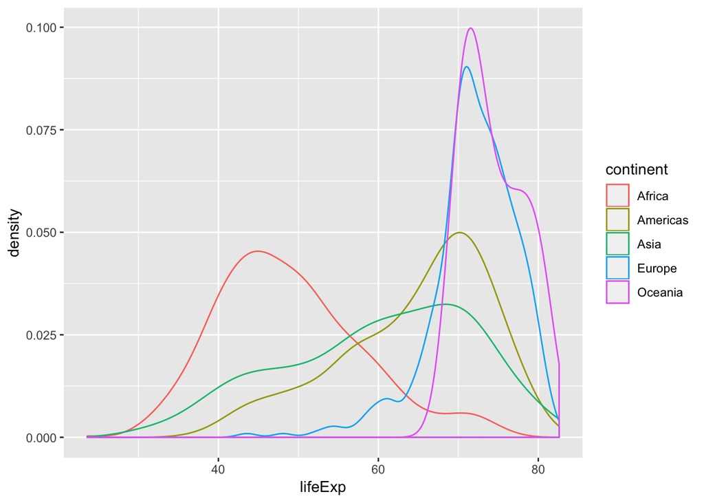

```r
ggplot(gapminder,
       aes(lifeExp, colour = continent)) +
       geom_density()
```

### Customizing your density plot

The below code shows you how to choose custom colors and split each continent plot.

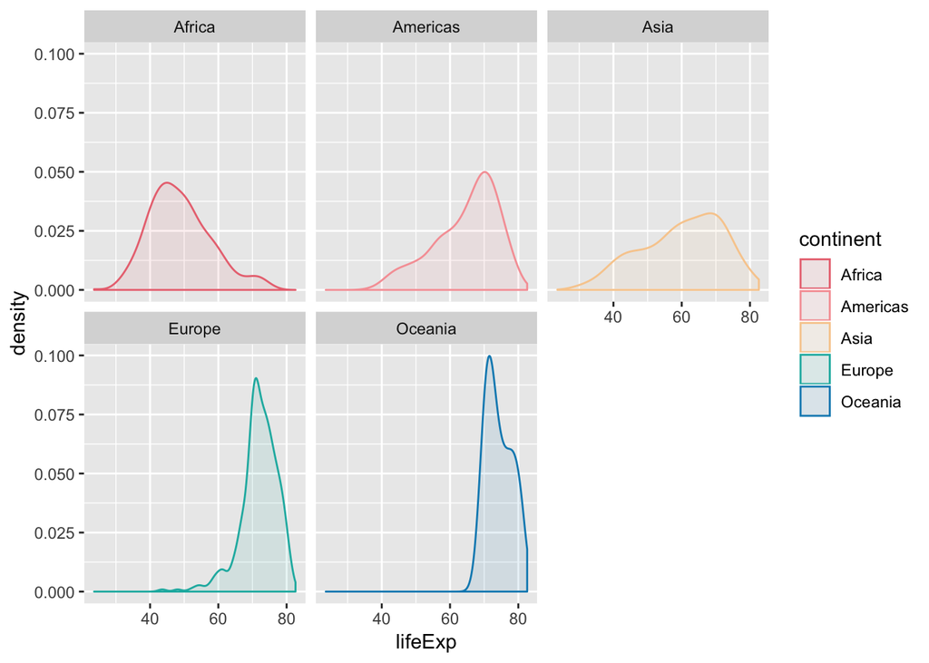

```r
# Store colors you want for each continent
density_plot_colors <- c( "Africa" = "#EA7580",
                          "Americas" = "#F6A1A5",
                          "Asia" = "#F8CD9C",
                          "Europe"= "#1BB6AF",
                          "Oceania" = "#088BBE")

ggplot(gapminder,
       aes(lifeExp, fill = continent, colour = continent)) +
       geom_density(alpha = 0.1) +
       scale_color_manual(values = density_plot_colors) +
       scale_fill_manual(values = density_plot_colors)  +
       facet_wrap(~continent)
```

## Histogram mistakes to avoid:

- **Minimize clutter and overlap**
- **Only plot numerical data**

## Histograms in Survey Analysis

How does knowing how to make histograms help you?

Let’s say you fielded a survey to 5,000 Uber riders. The survey received a 10% response rate, so a total of 500 respondents.

Is 10% a good response rate?

Well, let’s see if the respondents are *different* from those who didn’t respond to the survey. A quick lightweight way to visualize this is by plotting your data set.

Visualizing your data set should be one of the first steps you complete when conducting exploratory analysis.

Meaningful data we have on Uber riders in the sample include:

- days since they first signed up (tenure) and
- lifetime trips completed (lt_trips)

```r
set.seed(300)

#Generate a data set with fake sample respondents
sample <- tibble(
              respondent_id = 1:5000,
              tenure =  rnorm(n = 5000, mean = 900, sd=200),
              lt_trips = (c(runif(500, min = 1, max = 50), runif(1000, min = 51, max = 100), runif(3200, min = 101, max = 150), runif(300, min = 151, max = 200)))
)

#randomly sample 500 respondents from the sample data set and label them as "respondents"
respondents <- sample_n(sample, 500) %>%
              mutate(respondent_type = "respondent")
```

Let’s label the non-respondents in the `sample` data set in a column named `respondent_type`.

```r
nonrespondents <- sample %>%
                  anti_join(respondents, by = c("respondent_id" = "respondent_id")) %>%
                  mutate(respondent_type = "nonrespondent")

sample_recoded <- respondents %>%
                  bind_rows(nonrespondents)
```

Let’s calculate the average tenure and lifetime trips of the respondents and non-respondents

```r
sample_recoded_measures_of_ct <- sample_recoded %>%
  group_by(respondent_type) %>%
  summarize(mean_tenure = mean(tenure),
            mean_lt_trips = mean(lt_trips)
            )
```

Now, let’s plot the average tenure and lifetime trips.

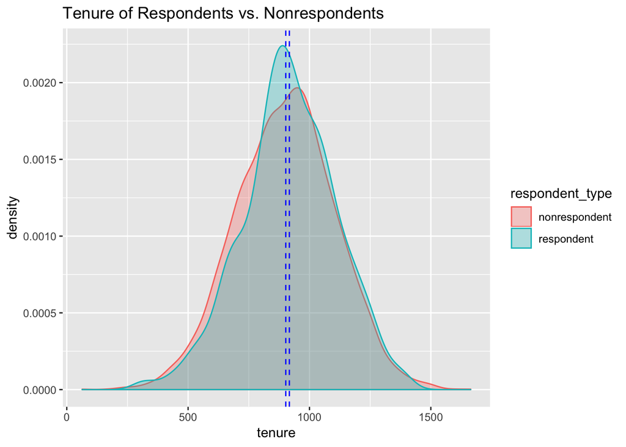

```r
ggplot(sample_recoded,
       aes(tenure,
           fill = respondent_type,
           colour = respondent_type)) +
        geom_density(alpha = 0.3) +
        geom_vline(data = sample_recoded_measures_of_ct,
                   aes(xintercept = mean_tenure),
                   linetype = "dashed", color = "blue") +
        labs(title = "Tenure of Respondents vs. Nonrespondents")
```

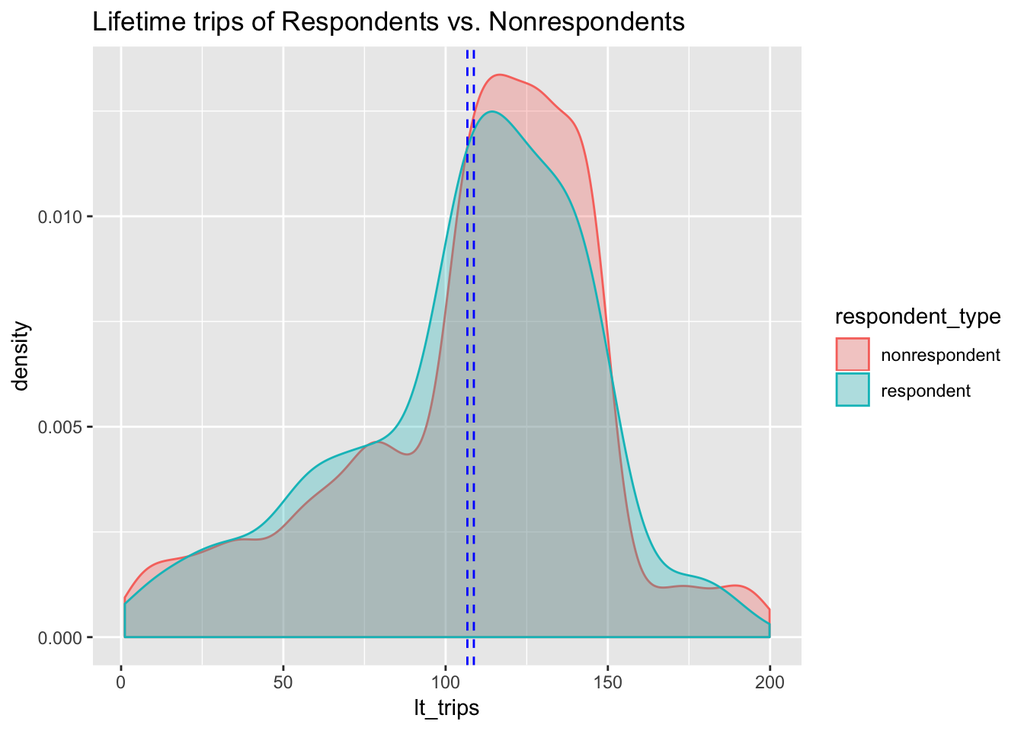

```r
ggplot(sample_recoded,
       aes(lt_trips,
           fill = respondent_type,
           colour = respondent_type)) +
        geom_density(alpha = 0.3) +
        geom_vline(data = sample_recoded_measures_of_ct,
                   aes(xintercept = mean_lt_trips),
                   linetype = "dashed", color = "blue") +
        labs(title = "Lifetime trips of Respondents vs. Nonrespondents")
```

From this visualization, we can see the respondents and non-respondents are likely similar groups.  
To further validate this, we can compare the means of the two groups. Check out Ryan’s workbook on Confidence Intervals to learn how to test means across two groups.

## But I’m still uncomfortable with R…

OK, we heard you. There’s a ramp up to R. If you’re still uncomfortable, you can view a histogram example using the same gapminder data set in Google sheets [here](https://docs.google.com/spreadsheets/d/1KC1Cx1nHfNrVRSom1QXc42q8S_VSo9KmJA9nrZx3Ils/edit?usp=sharing) and view a walk through on histograms on the Google support page [here](https://support.google.com/docs/answer/9146867?hl=en)

## Resources

Read more about different visualization types and how to build them from the following resources:

- [Data to Viz](https://www.data-to-viz.com/)  
  *From Data to Viz leads you to the most appropriate graph for your data. It links to the code to build it and lists common caveats you should avoid.*
- [Smoothed Density Estimates - ggplot2](https://ggplot2.tidyverse.org/reference/geom_density.html)  
  *Documentation on how to use the `geom_density` and `stat_density` plotting functions for ggplot2*
- [LaCroixColoR - LaCroix Color Palettes for R](https://github.com/johannesbjork/LaCroixColoR)  
  *Choose from 20 different LaCroix flavors to color your plots.*